# Species richness, abundance, distributional pattern and trait composition of butterfly assemblage change along an altitudinal gradient in the Gulmarg region of Jammu & Kashmir, India - ScienceDirect

## [Saudi Journal of Biological Sciences](https://www.sciencedirect.com/journal/saudi-journal-of-biological-sciences)

[Volume 29, Issue 4](https://www.sciencedirect.com/journal/saudi-journal-of-biological-sciences/vol/29/issue/4), April 2022, Pages 2262-2269

# Original article Species richness, abundance, distributional pattern and trait composition of butterfly assemblage change along an altitudinal gradient in the Gulmarg region of Jammu & Kashmir, India

https://doi.org/10.1016/j.sjbs.2021.11.066[Get rights and content](https://s100.copyright.com/AppDispatchServlet?publisherName=ELS&contentID=S1319562X21010317&orderBeanReset=true)

Under a Creative Commons [license](http://creativecommons.org/licenses/by/4.0/)

open access

## Keywords

Biodiversity

Lepidoptera

Altitudinal gradients

Butterflies

Gulmarg

## 1. Introduction

Lepidoptera is the second largest order of Class Insecta. It comprises two sub-orders, i.e., Moths (Heterocera) and Butterflies (Rhaplocera), consisting of about 124 families (Kristensen et al., 2007). According to Van Nieukerken et al. (2011), butterflies count for 1.87% of the global insect fauna. Butterflies are great focal species because they are involved in various environmental processes (Arroyo et al., 1982). Due to their diverse and abundant nature, they are easily identified, collected and sampled round the year. Thus proving to the best models for population and ecology (Pollard, 1991). They are considered valuable indicators of forests due to widespread distribution, different land-use systems (Dar and Jamal, 2021-a., Schulze et al., 2004) and land cover types (Soga et al., 2015). Their pollination efficiency is higher than that of bees at higher elevations. They account for 75% of the floral visitors of the Asteraceae family, one of the most common plant families in Brazilian grasslands (Mota et al., 2016). [Lepidopteran](https://www.sciencedirect.com/topics/earth-and-planetary-sciences/lepidopteran) species are highly sensitive to [climatic factors](https://www.sciencedirect.com/topics/earth-and-planetary-sciences/climatic-factor) such as temperature, humidity, rainfall, and [wind speed](https://www.sciencedirect.com/topics/earth-and-planetary-sciences/wind-velocity) (Bhardwaj et al., 2012), affecting their distribution across [environmental gradients](https://www.sciencedirect.com/topics/earth-and-planetary-sciences/environmental-gradient) seen in both mountainous and low-lying areas. They also have a close association with the vegetation, that they need for food and protection from predators, especially in the immature stages (Ferrer-Paris et al., 2013). The adults feed on floral nectar, due to this, they are less specialized to their host plant than the larvae. As a result, the distribution of butterfly species is linked to plant structure and community makeup (Carneiro et al., 2014). Availability of plant resources, habitat quality and quality of natural and semi-natural habitats are some of the factors that govern the distribution of butterflies. Mountains are ideal for exploring the effects of rising elevation and climate change on species diversity and abundance because they generate a variety of physical conditions in a relatively short distance. Patterns in species richness along altitudinal gradients are well-known ecological phenomena. However, there is a paucity of information about how ecological filtering processes affect the composition and features of butterfly assemblages at high altitudes. Altitudinal species gradients are shaped by long-term speciation processes, dispersal and extinction events (Mittelbach, 2010) and short-term ecological interactions with other organisms and the environment.

Many hypotheses provide a framework for understanding patterns of species richness and abundance along altitudinal gradients. The species energy theory predicts that as the altitude rises, species richness will decline due to increased energy availability and reduced population sizes at the mountain tops (Chown et al., 2012). Another hypothesis explains the decrease of biodiversity along altitude gradients with the species-area relationship (Lomolino, 2000). However, biodiversity does not always follow a linear pattern with increasing altitude and can peak at intermediate altitudes, possibly as a result of reduced biodiversity at low elevations due to [human impact](https://www.sciencedirect.com/topics/earth-and-planetary-sciences/anthropogenic-effect), highest productivity at mid-elevations, and the mid-domain effect, which explains a species richness peak at mid-elevation by stochastic effects of randomly distributed species that overlap more towards the centre of a geographical domain (Colwell et al., 2004). The presence or absence of any species is determined by the traits of the species. Species that live in similar environments and climates have similar traits. Cool-adapted species are moving northward and upward to avoid rising temperatures (Parmesan, 2006). Mountain-dwelling species moved their optimal elevation higher than non-mountain species (Lenoir et al., 2008). As a result, examining species traits that are sensitive to climatic and environmental variables, such as those found along altitudinal gradients, could help researchers better understand how species react to climate change (Diamond et al., 2011).

## 2. Materials & methods

### 2.1. Study area and survey sites

Gulmarg is a famous hill station in the Baramulla district of Jammu & Kashmir, located at 2650 m a.s.l in the Pir Panjal Range of the western [Himalayas](https://www.sciencedirect.com/topics/earth-and-planetary-sciences/himalayas). In Gulmarg, Six Survey sites, SI- S VI, were selected for accessing butterfly diversity (As shown in Fig. 1). These sites were selected according to the elevation. S I was located by 2700 m a.s.l, while as Site VI was located at 3200 m a.s.l. [Glacial deposits](https://www.sciencedirect.com/topics/earth-and-planetary-sciences/glacial-deposit), [lacustrine deposits](https://www.sciencedirect.com/topics/earth-and-planetary-sciences/lacustrine-deposit), and moraines cover shales, sandstones, schists, and other types of rocks found in it. During the spring and summer, the natural meadows of gulmarg are covered in snow during the winter. Enclosed parks and small lakes are interspersed throughout the fields, which are flanked by verdant pine and forests.

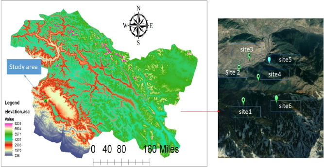

1. [Download : Download high-res image (634KB)](https://ars.els-cdn.com/content/image/1-s2.0-S1319562X21010317-gr1_lrg.jpg)
2. [Download : Download full-size image](https://ars.els-cdn.com/content/image/1-s2.0-S1319562X21010317-gr1.jpg)

Fig. 1. Sampling area and survey site of Gulmarg, Jammu and Kashmir.

### 2.2. Data collection

The field trips of the study area were undertaken from March 2018 to November 2020 to explore the butterfly diversity. In study area, six survey sites, (SI- S VI) were accessed for butterfly diversity and abundance. In each survey site, [GPS](https://www.sciencedirect.com/topics/earth-and-planetary-sciences/global-positioning-system) coordinates and above sea level length was measured by GPS Garmin Etrex. The butterflies were collected by sweeping net, followed by the photography of them. None of the butterfly species were killed during the collection.

### 2.3. Identification

The identification of butterflies was carried out with the help of identification keys, standard reference keys, available literature viz., (Smetacek, 2018, Kehimkar, 2016, Wynter-Blyth, 1957, Evans, 1932).

### 2.4. Diversity indices

H = Shannon index for species diversity,

S = Number of species,

P<sub>i</sub> = Proportion of total sample belonging to the i<sup>th</sup> species, and

ln = Natural log

Simpson’s diversity Index$SI=∑pi∗pi$Where:

[SI](https://www.sciencedirect.com/topics/earth-and-planetary-sciences/international-system-of-units) = Simpson’s Index of species diversity,

S = No. of species, and

pi = proportion of total sample belonging to the i<sup>th</sup> species

The Index is more sensitive to species abundance

N is the total number of individuals in the sample

n is the number of individual of species i

ln(x) refers to natural logarithm of x

It's a tool for determining the diversity of a population.

N is number of individuals

And a is fisher’s alpha

## 3. Results

Altogether we recorded 2023 individuals of butterflies, belonging to 40 species under 27 genera and 5 families. The different species of butterflies are presented in Table 1. Out of 2023 individuals of butterflies, 1121 individuals belong to the family Nymphalidae, followed by 513 individuals belonging to Pieridae, 314 individuals belong to Lycaenidae, 58 individuals belong to Papilionidae, and 17 individuals belong to Hesperiidae (As shown in Fig. 2). The Nymphalidae family had the most species, with 23, followed by Lycaenidae with 8, Pieridae with 7, Papilionidae and Hesperiidae with 1 each (As shown in Fig. 3). The Nymphalidae family had the most genera 16, followed by Lycaenidae with 5 genera, Pieridae with 04 genera, Papilionidae and Hesperiidae with 01 genera each.

Table 1. Butterfly fauna recorded from the survey sites of Gulmarg region of J&K.

| S. No | Species | Total no. of individuals | Family | Author & Year |
| --- | --- | --- | --- | --- |
| 01 | *Junonia iphita siccata* | 55 | Nymphalidae | (Fruhstorfer, 1900) |
| 02 | *Junonia orithya swinhoei* | 48 | Nymphalidae | (Butler, 1885) |
| 03 | *Junonia hiertha* | 37 | Nymphalidae | (Fabricius, 1798) |
| 04 | *Aulocera brahminus* | 65 | Nymphalidae | (Blanchard, 1853) |
| 05 | *Aulocera padma* | 76 | Nymphalidae | (Kollar, 1844) |
| 06 | *Aulocera swaha garuna* | 46 | Nymphalidae | (Frushstorfer, 1911) |
| 07 | *Hyponephele coenonympha* | 66 | Nymphalidae | (C. & R. Felder, 1867) |
| 08 | *Hyponephele kashmirica* | 75 | Nymphalidae | (Moore, 1892) |
| 09 | *Vanessa cardui* | 68 | Nymphalidae | (Linnaeus, 1758) |
| 10 | *Vanessa indica* | 89 | Nymphalidae | (Herbst, 1794) |
| 11 | *Argynnis hyperbius* | 38 | Nymphalidae | (Linnaeus, 1763) |
| 12 | *Argynius childreni* | 37 | Nymphalidae | (Kollar, 1848) |
| 13 | *Aglais caschmirensis* | 30 | Nymphalidae | (Kollar, 1884) |
| 14 | *Melanitis phedima galkissa* | 31 | Nymphalidae | (Fruhstorfer, 1911) |
| 15 | *Libythea lepita* | 56 | Nymphalidae | (Moore, 1858) |
| 16 | *Kaniska canace* | 29 | Nymphalidae | (Linnaeus, 1763) |
| 17 | *Neptis hylas kamarupa* | 33 | Nymphalidae | (Moore, 1875) |
| 18 | *Callerebia nirmala daksha* | 90 | Nymphalidae | (Moore, 1874) |
| 19 | *Kirinia eversmanni cashmirensis* | 37 | Nymphalidae | (Moore, 1874) |
| 20 | *Lasiommata scharka* | 20 | Nymphalidae | (Kollar, 1844) |
| 21 | *Nymphalis vaualbum* | 15 | Nymphalidae | (Denis & Schiffermuller, 1775) |
| 22 | *Hypolimnas misippus* | 31 | Nymphalidae | (Linnaeus, 1764) |
| 23 | *Issoria lathonia issaea* | 49 | Nymphalidae | (Gray, 1864) |
| 24 | *Colias fieldi* | 74 | Pieridae | (Menetries, 1855) |
| 25 | *Colias erate* | 66 | Pieridae | (Esper, 1805) |
| 26 | *Pieris brassicae nepalensi* | 102 | Pieridae | (Gray, 1846) |
| 27 | *Pieris canidia indica* | 94 | Pieridae | (Evans, 1926) |
| 28 | *Aporia nabellica* | 46 | Pieridae | (Bosiduval, 1836) |
| 29 | *Aporia soracta* | 38 | Pieridae | (Moore, 1857) |
| 30 | *Pontia daplidice moorei* | 93 | Pieridae | (Rober, 1907) |
| 31 | *Rapala nissa* | 35 | Lycaenidae | (Moore, 1857) |
| 32 | *Rapala selira* | 47 | Lycaenidae | (Moore, 1847) |
| 33 | *Celastrina gigas* | 24 | Lycaenidae | (Hemming, 1928) |
| 34 | *Celastrina argiolus kollari* | 33 | Lycaenidae | (Westwood, 1852) |
| 35 | *Lycaena phlaeas baralacha* | 48 | Lycaenidae | (Linnaeus, 1761) |
| 36 | *Lycaena kasyapa* | 34 | Lycaenidae | (Moore, 1865) |
| 37 | *Aricia agestis nazira* | 17 | Lycaenidae | (Moore, 1865) |
| 38 | *Lampides boeticus* | 76 | Lycaenidae | (Linnaeus, 1767) |
| 39 | *Papilio machaon asiatica* | 58 | Papilionidae | (Menetries, 1855) |
| 40 | *Pelopidas mathias* | 17 | Hesperiidae | (Fabricius, 1798) |
| Total |  | 2023 |  |  |

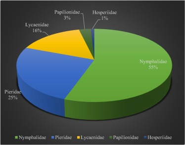

1. [Download : Download high-res image (103KB)](https://ars.els-cdn.com/content/image/1-s2.0-S1319562X21010317-gr2_lrg.jpg)
2. [Download : Download full-size image](https://ars.els-cdn.com/content/image/1-s2.0-S1319562X21010317-gr2.jpg)

Fig. 2. The species abundance of butterfly fauna in relation to their families in Gulmarg region of Jammu & Kashmir.

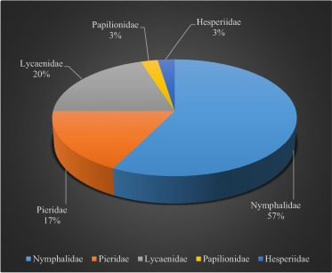

1. [Download : Download high-res image (105KB)](https://ars.els-cdn.com/content/image/1-s2.0-S1319562X21010317-gr3_lrg.jpg)
2. [Download : Download full-size image](https://ars.els-cdn.com/content/image/1-s2.0-S1319562X21010317-gr3.jpg)

Fig. 3. The species richness of butterfly fauna in relation to their families in Gulmarg region of Jammu & Kashmir.

### 3.1. Diversity indices along altitudinal gradient

When diversity indices are applied, interpreting species distribution becomes easier. According to Barrantes and Sandoval, (2009), using multiple indices helps eliminate drawbacks of the individual index. Shannon’s Index describes species diversity. Maximum species diversity was observed for Site I (2.92), and minimum diversity for Site VI (1.261). When Shannon’s index is calculated, a weighted geometric mean of the proportional abundances is employed. Thus, it reflects the logarithm of actual diversity observed and is used frequently. Simpson’s index uses the weighted arithmetic mean or proportional abundances and describes species richness and evenness. Thus, a high Simpson’s index suggests higher species richness and evenness. The maximum value for Simpson’s index was calculated for Site I (0.9413) and the minimum for Site VI (0.6784). This suggests that the species richness at Site I is definitely high and there is an evenness to the species distribution too.

The following index calculated was Brillouin’s index. According to Magurran, (1988), this diversity index serves better when there is no surety for the randomness of the sample. Thus, to eliminate any biases raised unknowingly, we employed this index. The maximum value for this index was calculated again for Site I (2.859) and the minimum for Site VI (1.195). Lastly, Fisher’s alpha was the fourth alpha diversity index employed. In cases where sample sizes vary a lot, Fisher’s alpha has a good discriminating capability. As the sample size for all the sampling stations varied, this index was used. Maximum value for this index was calculated for Site I (3.881) and the minimum for Site VI (0.8299). Thus, all the four alpha diversity indices confirm that maximum alpha diversity was observed at Site I and minimum at Site VI (As shown in Table 2). A Similar type of research was carried out by (Ahmad Dar et al., 2021, Dar and Jamal, 2021-b., Naz et al., 2021, Liu et al., 2019, Bokhorst et al., 2018, Qing et al., 2015, Illig et al., 2010, Cutz-Pool et al., 2010). They also concluded that, diversity indices show a decrease in diversity and abundance decreases along an altitudinal gradient.

Table 2. Diversity indices for survey sites.

| Diversity Indices | Site I | Site II | Site III | Site IV | Site V | Site VI |
| --- | --- | --- | --- | --- | --- | --- |
| No. of Taxa | 21 | 16 | 12 | 08 | 06 | 04 |
| Individuals sites | 865 | 403 | 366 | 148 | 139 | 102 |
| Simpson’s Index | 0.9413 | 0.9277 | 0.8556 | 0.823 | 0.798 | 0.6784 |
| Shannon-Weiner Index | 2.92 | 2.692 | 2.138 | 1.878 | 1.679 | 1.261 |
| Brillouin’s Index | 2.859 | 2.603 | 2.069 | 1.778 | 1.599 | 1.195 |
| Fisher’s alpha | 3.881 | 3.331 | 2.38 | 1.812 | 1.277 | 0.8299 |

### 3.2. Change in abundance of butterfly community along altitudinal gradient

Table 3. Butterfly fauna at survey sites (S I- S VI) showing elevation, abundance and [GPS](https://www.sciencedirect.com/topics/earth-and-planetary-sciences/global-positioning-system) Coordinates.

Sites

Elevationm a.s.l

Species found

Total no. of Individuals

GPS Coordinates

I

2700

- 1.

  *Colias fieldi*
- 2.

  *Colias erate*
- 3.

  *Pieris brassicae nepalensi*
- 4.

  *Pieris canidia indica*
- 5.

  *Aporia nabellica*
- 6.

  *Aporia soracta*
- 7.

  *Junonia iphita siccata*
- 8.

  *Junonia orithya swinhoei*
- 9.

  *Hyponephele coenonympha*
- 10.

  *Hyponephele kashmirica*
- 11.

  *Argynnis hyperbius*
- 12.

  *Melanitis phedima galkissa*
- 13.

  *Libythea lepita*
- 14.

  *Kaniska canace*
- 15.

  *Nymphalis vaualbum*
- 16.

  *Lampides boeticus*
- 17.

  *Celastrina gigas*
- 18.

  *Pontia dalpidice moorie*
- 19.

  *Pelopidas mathias*
- 20.

  *Callerebia nirmala daksha*
- 21.

  *Kirinia eversmanni cashmirensis*

50  
45  
60  
48  
46  
38  
32  
35  
66  
75  
23  
20  
56  
18  
9  
76  
24  
60  
17  
53  
14

34°11′20.58′′N  
74°12′3.22′′E

II

2800

- 1.

  *Colias fieldi*
- 2.

  *Colias erate*
- 3.

  *Pieris brassicae nepalensi*
- 4.

  *Pieris canidia indica*
- 5.

  *Rapala selira*
- 6.

  *Rapala nissa*
- 7.

  *Lycaena phlaeas baralacha*
- 8.

  *Lycaena kasyapa*
- 9.

  *Jononia ipitha siccata*
- 10.

  *Junonia orithya swinhoei*
- 11.

  *Celastrina argiolus kollari*
- 12.

  *Pontia daplidice moorei*
- 13.

  *Argynnis hyperbius*
- 14.

  *Melanitis phedima galkissa*
- 15.

  *Kaniska canace*
- 16.

  *Callerebia nirmala daksha*

24  
21  
30  
32  
47  
25  
30  
34  
23  
13  
17  
33  
15  
11  
11  
37

34°11′12.96′′N  
74°10′56.56′′E

III

2900

- 1.

  *Pieris brassicae nepalensi*
- 2.

  *Pieris canidia indica*
- 3.

  *Aulocera brahminus*
- 4.

  *Aulocera padma*
- 5.

  *Vanessa cardui*
- 6.

  *Vanessa indica*
- 7.

  *Kirinia eversmanni cashmirensis*
- 8.

  *Nymphalis vaulbum*
- 9.

  *Lycaena phlaeas baralacha*
- 10.

  *Rapala nissa*
- 11.

  *Celastrina argiolus kollari*
- 12.

  *Junonia hiertha*

12  
14  
65  
42  
68  
81  
10  
6  
11  
10  
10  
37

34°12′1.08′′N  
74°11′27.92′′E

IV

3000

- 1.

  *Lycaena phlaeas baralacha*
- 2.

  *Kirinia eversmanni cashmirensis*
- 3.

  *Aulocera padma*
- 4.

  *Argynnis hyperbius*
- 5.

  *Celastrina argiolus kollari*
- 6.

  *Hypolimnas misippus*
- 7.

  *Papilao machaon asiatica*
- 8.

  *Aglais cascmirensis*

7  
13  
34  
8  
6  
21  
40  
19

34°12′54.07′′N  
74°10′10.27′′E

V

3100

- 1.

  *Argynius childreni*
- 2.

  *Neptis hylas kamarupa*
- 3.

  *Aglais cascmirensis*
- 4.

  *Hypolimnas misippus*
- 5.

  *Papilio machaon asiatica*
- 6.

  *Aulocera swaha garuna*

37  
33  
11  
10  
18  
30

34°13′12.65′′N  
74°10′6.28′′E

VI

3200

- 1.

  *Aricia agestis nazira*
- 2.

  *Issoria lathonia issea*
- 3.

  *Lasiommata scharka*
- 4.

  *Aulocera swaha garuna*

17  
49  
20  
16

34°13′39.49′′N  
74°9′28.67′′E

### 3.3. Change in species richness of butterfly community along elevation gradient

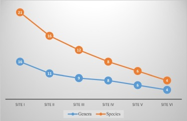

1. [Download : Download high-res image (72KB)](https://ars.els-cdn.com/content/image/1-s2.0-S1319562X21010317-gr4_lrg.jpg)
2. [Download : Download full-size image](https://ars.els-cdn.com/content/image/1-s2.0-S1319562X21010317-gr4.jpg)

Fig. 4. Number of genera and species in relation of survey sites (SI- SVI).

## 4. Discussion

Studies involving the conservation of butterfly diversity are vital as Lepidoptera are an integral part of the [food chain](https://www.sciencedirect.com/topics/earth-and-planetary-sciences/food-chain) connecting [autotrophs](https://www.sciencedirect.com/topics/earth-and-planetary-sciences/autotroph) and [heterotrophs](https://www.sciencedirect.com/topics/earth-and-planetary-sciences/heterotroph). They are also well-known ecological indicators, sensitive to climatic and ecological changes and respond quickly to the stratification of the vegetation in terms of temperature, wind, light and humidity (Dar and Jamal, 2021). Moreover, studying the diversity of butterflies provide us with insight information about changes in abundance, evenness and richness affected by vegetation and species interactions and landscapes. The information about the species diversity, richness and abundance help in constructing conservation measures and management practices.

## Declaration of Competing Interest

The authors declare that they have no known competing financial interests or personal relationships that could have appeared to influence the work reported in this paper.

## Acknowledgement

The authors are highly thankful to the Chairperson, Department of Zoology, Aligarh Muslim University, for providing the necessary facilities to carry out this research work. Moreover, the first author is also grateful to Aamir Hameed War for assisting during the field surveys. In addition, the first author wishes to express his gratitude to Dr. Rifat Ara for her unwavering support throughout the journey of this paper. This study was funded by Taif University Researchers Supporting Project number (TURSP-2020/92), Taif University, Taif, Saudi Arabia.

## References

1. Afzal et al., 2021

   S. Afzal, H. Nesar, Z. Imran, W. Ahmad

   Altitudinal gradient affect abundance, diversity and metabolic footprint of soil nematodes in Banihal-Pass of Pir-Panjal mountain range

   Sci. Rep., 11 (2021), pp. 1-13

   [CrossRef](https://doi.org/10.5455/ijmrcr.breast-seroma-fistula)Google Scholar
2. Antão et al., 2020

   L.H. Antão, J. Pöyry, R. Leinonen, T. Roslin, L. Lancaster

   Contrasting latitudinal patterns in diversity and stability in a high-latitude species-rich moth community

   Glob. Ecol. Biogeogr., 29 (5) (2020), pp. 896-907

   [CrossRef](https://doi.org/10.1111/geb.13073)[View in Scopus](https://www.scopus.com/inward/record.url?eid=2-s2.0-85079846448&partnerID=10&rel=R3.0.0)Google Scholar
3. Arroyo et al., 1982

   M.K. Arroyo, R. Primack, J. Armesto

   Community studies in pollination ecology in the high temperate Andes of central Chile. I pollination mechanisms, altitudinal variation

   Am. J. Bot., 69 (1982), pp. 82-97

   Google Scholar
4. Barrantes and Sandoval, 2009

   Barrantes, G., Sandoval, L., 2009. Conceptual and statistical problems associated with the use of diversity indices in ecology. Rev. Biol. Trop. 57, 451–460. http://doi.org/10.15517/rbt.v57i3.5467.

   Google Scholar
5. Berner et al., 2004

   D. Berner, C. Körner, W.U. Blanckenhorn

   Grasshopper populations across 2000 m of altitude: is there life history adaptation?

   Ecography, 27 (2004), pp. 733-740, 10.1111/j.0906-7590.2005.04012.x

   [View in Scopus](https://www.scopus.com/inward/record.url?eid=2-s2.0-11144251586&partnerID=10&rel=R3.0.0)[Google Scholar](https://scholar.google.com/scholar?q=Grasshopper%20populations%20across%202000%20m%20of%20altitude:%20is%20there%20life%20history%20adaptation)
6. Bhardwaj et al., 2012

   M. Bhardwaj, V.P. Uniyal, A.K. Sanyal, A.P. Singh

   Butterfly communities along an elevational gradient in the Tons valley, Western Himalayas: Implications of rapid assessment for insect conservation

   J. Asia-Pac. Entomol., 15 (2) (2012), pp. 207-217

   [View PDF](https://www.sciencedirect.com/science/article/pii/S1226861511001373/pdfft?md5=d888d648fca293a6747789983284ebef&pid=1-s2.0-S1226861511001373-main.pdf)[View article](https://www.sciencedirect.com/science/article/pii/S1226861511001373)[View in Scopus](https://www.scopus.com/inward/record.url?eid=2-s2.0-84863403692&partnerID=10&rel=R3.0.0)Google Scholar
7. Bokhorst et al., 2018

   S. Bokhorst, G.F. (Ciska) Veen, M. Sundqvist, J.R. De Long, P. Kardol, D.A. Wardle

   Contrasting responses of springtails and mites to elevation and vegetation type in the sub-Arctic

   Pedobiologia, 67 (2018), pp. 57-64

   [View PDF](https://www.sciencedirect.com/science/article/pii/S0031405617302603/pdfft?md5=6ca83344e9d814158ee6c2e6cc05c1b2&pid=1-s2.0-S0031405617302603-main.pdf)[View article](https://www.sciencedirect.com/science/article/pii/S0031405617302603)[View in Scopus](https://www.scopus.com/inward/record.url?eid=2-s2.0-85042484222&partnerID=10&rel=R3.0.0)Google Scholar
8. Camero et al., 2007

   E. Camero, M. Anderson, C. Calderon

   Comunidad de mariposas diurnas (Lepidoptera:Rhopalocera) en un gradiente altitudinal del cañón del río Combeima-Tolima, Colombia

   Acta Biológica Colombiana, 12 (2007), pp. 95-110

   [Google Scholar](https://scholar.google.com/scholar?q=Comunidad%20de%20mariposas%20diurnas%20%20en%20un%20gradiente%20altitudinal%20del%20ca%C3%B1%C3%B3n%20del%20r%C3%ADo%20Combeima-Tolima,%20Colombia)
9. Carneiro et al., 2014

   Carneiro, E., Mielke, O.H.H., Casagrande, M.M., Fiedler, K., 2014. Skipper richness (Hesperiidae) along elevational gradients in Brazilian Atlantic Forest. Neotropical Entomol. 43, 27–38.

   Google Scholar
10. Chown et al., 2012

    Chown, S.L., Roux, P.C.L., Ramaswiela, T., et al., 2012. Climate change and elevational diversity capacity: do weedy species take up the slack? Biol. Lett. 9, 20120806. https://doi.org/10.1098/rsbl.2012.0806.

    Google Scholar
11. Clark et al., 2007

    P.J. Clark, J.M. Reed, F.S. Chew

    Effects of urbanization on butterfly species richness, guild structure, and rarity

    Urban Ecosyst., 10 (3) (2007), pp. 321-337

    [CrossRef](https://doi.org/10.1007/s11252-007-0029-4)[View in Scopus](https://www.scopus.com/inward/record.url?eid=2-s2.0-34547922733&partnerID=10&rel=R3.0.0)Google Scholar
12. Colwell et al., 2004

    R. Colwell, C. Rahbek, N. Gotelli

    The mid-domain effect and species richness patterns: what have we learned so far?

    Am Nat., 163 (3) (2004), pp. E1-E23, 10.1086/382056

    [Google Scholar](https://scholar.google.com/scholar?q=The%20mid-domain%20effect%20and%20species%20richness%20patterns:%20what%20have%20we%20learned%20so%20far)
13. Cutz-Pool et al., 2010

    L.Q. Cutz-Pool, J.G. Palacios-Vargas, Z. Cano-Santana, G. Castaño-Meneses

    Diversity patterns of Collembola in an elevational gradient in the NW slope of Iztaccíhuatl volcano, state of Mexico, Mexico

    Entomol. News., 121 (3) (2010), pp. 249-261

    [CrossRef](https://doi.org/10.3157/021.121.0306)[View in Scopus](https://www.scopus.com/inward/record.url?eid=2-s2.0-80053548547&partnerID=10&rel=R3.0.0)Google Scholar
14. Dar and Jamal, 2021

    A.A. DAR, K. JAMAL

    Moth (Insecta: Lepidoptera) fauna of Sariska Tiger Reserve, Rajasthan, India

    Notulae Scientia Biologicae., 13 (2) (2021), p. 10906, 10.15835/nsb13210906

    [View in Scopus](https://www.scopus.com/inward/record.url?eid=2-s2.0-85112122096&partnerID=10&rel=R3.0.0)[Google Scholar](https://scholar.google.com/scholar?q=Moth%20%20fauna%20of%20Sariska%20Tiger%20Reserve,%20Rajasthan,%20India)
15. Dar and Jamal, 2021-a.

    A.A. Dar, K. Jamal

    Moths as ecological indicators: A review

    Munis Entomol. Zool., 16 (2021-a.), pp. 833-839

    [Google Scholar](https://scholar.google.com/scholar?q=Moths%20as%20ecological%20indicators:%20A%20review)
16. Dar and Jamal, 2021-b.

    A.A. Dar, K. Jamal

    The decline of moths globally: A review of possible causes

    Munis Entomol. Zool., 16 (2021-b.), pp. 317-326

    [CrossRef](https://doi.org/10.1007/978-3-030-51485-3_21)[View in Scopus](https://www.scopus.com/inward/record.url?eid=2-s2.0-85096549530&partnerID=10&rel=R3.0.0)[Google Scholar](https://scholar.google.com/scholar?q=The%20decline%20of%20moths%20globally:%20A%20review%20of%20possible%20causes)
17. Ahmad Dar et al., 2021

    A. Ahmad Dar, K. Jamal, A. Alhazmi, M. El-Sharnouby, M. Salah, S. Sayed

    Moth diversity, species composition, and distributional pattern in Aravalli Hill Range of Rajasthan, India

    Saudi J. Biol. Sci., 28 (9) (2021), pp. 4884-4890, 10.1016/j.sjbs.2021.06.018

    [View PDF](https://www.sciencedirect.com/science/article/pii/S1319562X21004782/pdfft?md5=773289197be2754eaf0d090137668005&pid=1-s2.0-S1319562X21004782-main.pdf)[View article](https://www.sciencedirect.com/science/article/pii/S1319562X21004782)[View in Scopus](https://www.scopus.com/inward/record.url?eid=2-s2.0-85108790914&partnerID=10&rel=R3.0.0)Google Scholar
18. Diamond et al., 2011

    S.E. Diamond, A.M. Frame, R.A. Martin, L.B. Buckley

    Species’ traits predict phenological responses to climate change in butterflies

    Ecology, 92 (5) (2011), pp. 1005-1012

    [View in Scopus](https://www.scopus.com/inward/record.url?eid=2-s2.0-79955889325&partnerID=10&rel=R3.0.0)[Google Scholar](https://scholar.google.com/scholar?q=Species%20traits%20predict%20phenological%20responses%20to%20climate%20change%20in%20butterflies)
19. Evans, 1932

    Evans, W.H., 1932. The identification of Indian Butterflies. (Second edition revised) J. Bom. Nat. His. Soc. Madras., pp. 454.

    [Google Scholar](https://scholar.google.com/scholar?q=Evans,%20W.H.,%201932.%20The%20identification%20of%20Indian%20Butterflies.%20%20J.%20Bom.%20Nat.%20His.%20Soc.%20Madras.,%20pp.%20454.)
20. Ferrer-paris et al., 2013

    J.R. Ferrer-paris, A. Sánchez-mercado, A.L. Viloria, J. Donaldson

    Congruence, diversity of butterfly host plant associations at higher taxonomic levels

    PLoS ONE, 8 (2013), pp. 1-15

    Google Scholar
21. Gaston et al., 2008

    K.J. Gaston, S.L. Chown, K.L. Evans

    Ecogeographical rules: elements of a synthesis

    J. Biogeogr., 35 (2008), pp. 483-500, 10.1111/j.1365-2699.2007.01772.x

    [View in Scopus](https://www.scopus.com/inward/record.url?eid=2-s2.0-39149121172&partnerID=10&rel=R3.0.0)[Google Scholar](https://scholar.google.com/scholar_lookup?title=Ecogeographical%20rules%3A%20elements%20of%20a%20synthesis&publication_year=2008&author=K.J.%20Gaston&author=S.L.%20Chown&author=K.L.%20Evans)
22. Grytnes and McCain, 2007

    Grytnes, J.A., Mccain, C.M., 2007. Elevational trends in biodiversity. In: Levin S (Ed), Encyclopedia of Biodiversity. Elsevier, Amsterdam. 2, 1-8. https://doi.org/10.1038/NCLIMATE1347.

    Google Scholar
23. Illig et al., 2010

    J. Illig, R.A. Norton, S. Scheu, M. Maraun

    Density and community structure of soil- and bark-dwelling microarthropods along an altitudinal gradient in a tropical montane rainforest

    Exp. Appl. Acarol., 52 (1) (2010), pp. 49-62

    [CrossRef](https://doi.org/10.1007/s10493-010-9348-x)[View in Scopus](https://www.scopus.com/inward/record.url?eid=2-s2.0-77955176253&partnerID=10&rel=R3.0.0)Google Scholar
24. IMD | Home [WWW Document]., n.d.

    IMD | Home [WWW Document], n.d. URL https://mausam.imd.gov.in/ (accessed 9.5.21).

    [Google Scholar](https://scholar.google.com/scholar?q=IMD%20%20Home%20WWW%20Document,%20n.d.%20URL%20https:mausam.imd.gov.in%20.)
25. Joshi and Arya, 2007

    P.C. Joshi, M. Arya

    Butterfly communities along altitudinal gradients in a protected forest in the Western Himalayas, India

    Nat. Hist. J. Chulalongkorn Univ., 7 (2007), pp. 1-9

    Google Scholar
26. Joshi et al., 2008

    P.C. Joshi, K. Kumar, M. Arya

    Assessment of insect diversity along an altitudinal gradient in Pinderi forests of Western Himalaya, India

    IndiaJ. Asia Pac. Entomol., 11 (1) (2008), pp. 5-11

    [View PDF](https://www.sciencedirect.com/science/article/pii/S1226861508000034/pdfft?md5=ea0b7c4a14e31bd36a8ea51078a48e0f&pid=1-s2.0-S1226861508000034-main.pdf)[View article](https://www.sciencedirect.com/science/article/pii/S1226861508000034)[View in Scopus](https://www.scopus.com/inward/record.url?eid=2-s2.0-45449110993&partnerID=10&rel=R3.0.0)Google Scholar
27. Karl et al., 2008

    I. Karl, S.A. Janowitz, K. Fischer

    Altitudinal life-history variation and thermal adaptation in the copper butterfly Lycaena tityrus

    Oikos, 117 (2008), pp. 778-788, 10.1111/j.2008.0030-1299.16522.x

    [View in Scopus](https://www.scopus.com/inward/record.url?eid=2-s2.0-42949145886&partnerID=10&rel=R3.0.0)Google Scholar
28. Kehimkar, 2016

    I. Kehimkar

    BNHS Field Guides: Butterflies of India

    Bomb Nat. Hist. Soc, India (2016), p. 506

    [Google Scholar](https://scholar.google.com/scholar_lookup?title=BNHS%20Field%20Guides%3A%20Butterflies%20of%20India&publication_year=2016&author=I.%20Kehimkar)
29. Kristensen et al., 2007

    N. Kristensen, M.J. Scoble, O. Karsholt

    Lepidoptera phylogeny and systematics: The state of inventorying moth and butterfly diversity

    Zootaxa., 747 (2007), pp. 699-747

    [CrossRef](https://doi.org/10.11646/zootaxa.1668.1.30)Google Scholar
30. Lang, 1868

    A.M. Lang

    Notes on Lepidoptera from “Goolmurg” in Cashmere. Entomol'.s Mon

    Mag., 5 (1868), pp. 33-37

    [Google Scholar](https://scholar.google.com/scholar?q=Notes%20on%20Lepidoptera%20from%20Goolmurg%20in%20Cashmere.%20Entomol.s%20Mon)
31. Lee et al., 2014

    C.M. Lee, T.-S. Kwon, S.-S. Kim, J.-D. Sohn, B.-W. Lee

    Effects of forest degradation on butterfly communities in the Gwangneung forest

    Entomol. Sci., 17 (3) (2014), pp. 293-301

    [CrossRef](https://doi.org/10.1111/ens.12062)[View in Scopus](https://www.scopus.com/inward/record.url?eid=2-s2.0-84903577232&partnerID=10&rel=R3.0.0)Google Scholar
32. Leingärtner et al., 2014

    A. Leingärtner, J. Krauss, I. Steffan-Dewenter

    Species richness and trait composition of butterfly assemblages change along an altitudinal gradient

    Oecologia, 175 (2) (2014), pp. 613-623, 10.1007/s00442-014-2917-7

    [View in Scopus](https://www.scopus.com/inward/record.url?eid=2-s2.0-84901195004&partnerID=10&rel=R3.0.0)Google Scholar
33. Lenoir et al., 2008

    J. Lenoir, J.C. Gégout, P.A. Marquet, P. de Ruffray, H. Brisse

    A significant upward shift in plant species optimum elevation during the 20th century

    Science, 320 (5884) (2008), pp. 1768-1771, 10.1126/science:1156831

    [View in Scopus](https://www.scopus.com/inward/record.url?eid=2-s2.0-46449109356&partnerID=10&rel=R3.0.0)Google Scholar
34. Liu et al., 2019

    J. Liu, Q. Yang, E. Siemann, W. Huang, J. Ding

    Latitudinal and altitudinal patterns of soil nematode communities under tallow tree (Triadica sebifera) in China

    Plant Ecol., 220 (10) (2019), pp. 965-976

    [CrossRef](https://doi.org/10.1007/s11258-019-00966-5)[View in Scopus](https://www.scopus.com/inward/record.url?eid=2-s2.0-85070888039&partnerID=10&rel=R3.0.0)[Google Scholar](https://scholar.google.com/scholar?q=Latitudinal%20and%20altitudinal%20patterns%20of%20soil%20nematode%20communities%20under%20tallow%20tree%20%20in%20China)
35. Lomolino, 2000

    M.V. Lomolino

    Ecology’s most general, yet protean pattern: the species–area relationship

    J. Biogeogr., 27 (2000), pp. 17-26, 10.1046/j.1365-2699.2000.00377.x

    [View in Scopus](https://www.scopus.com/inward/record.url?eid=2-s2.0-0033898186&partnerID=10&rel=R3.0.0)[Google Scholar](https://scholar.google.com/scholar?q=Ecologys%20most%20general,%20yet%20protean%20pattern:%20the%20speciesarea%20relationship)
36. Magurran, 1988

    Magurran, A.E., 1988. Choosing and interpreting diversity measures. Ecological Diversity and Its Measurement. Springer, Dordrecht. 61–80. http://doi.org/10.1007/978-94-015-7358-0_4.

    Google Scholar
37. Mittelbach, 2010

    G.G. Mittelbach

    Understanding species richness—productivity relationships: the importance of metaanalyses

    Ecology, 91 (9) (2010), pp. 2540-2544

    [CrossRef](https://doi.org/10.1890/09-1029.1)[View in Scopus](https://www.scopus.com/inward/record.url?eid=2-s2.0-77956589138&partnerID=10&rel=R3.0.0)[Google Scholar](https://scholar.google.com/scholar?q=Understanding%20species%20richnessproductivity%20relationships:%20the%20importance%20of%20metaanalyses)
38. Montero-Munoz et al., 2013

    J.L. Montero-Munoz, C. Pozo, M.F. Cepeda-Gonzalez

    Recambio temporal de especies de lepidópteros nocturnos en función de la temperatura y la humedad en una zona de selva caducifolia en Yucatán, México

    Acta Zoológica Mexicana., 29 (2013), pp. 614-628

    [CrossRef](https://doi.org/10.21829/azm.2013.2931601)Google Scholar
39. Moore, 1874

    Moore, F., 1874. List of Diurnal Lepidoptera collected in Cashmere Territory by Capt. R. B. Reed, 12th Regt. with Descriptions of new Species. Proc. Zool. Soc. Lond. 4, 264–274. http://doi.org/10.1111/j.1096-3642.1874.tb02482.x.

    Google Scholar
40. Mota et al., 2016

    N.M. Mota, V.L. Rezende, G. da Silva Mota, G.W. Fernandes, Y.R.F. Nunes

    Forces driving the regeneration component of a rupestrian grassland complex along an altitudinal gradient

    Brazilian J. Bot., 39 (2016), pp. 845-860

    [CrossRef](https://doi.org/10.1007/s40415-016-0287-6)[View in Scopus](https://www.scopus.com/inward/record.url?eid=2-s2.0-84987662336&partnerID=10&rel=R3.0.0)Google Scholar
41. Naz et al., 2021

    H. Naz, M.K. Usmani, M. Ali, S. Mobin, M.I. Khan

    Acridoid diversity, species composition and distributional pattern in Terai region of Uttarakhand, India

    Int. J. Trop. Insect Sci., 41 (1) (2021), pp. 547-553

    [CrossRef](https://doi.org/10.1007/s42690-020-00239-z)[View in Scopus](https://www.scopus.com/inward/record.url?eid=2-s2.0-85089754981&partnerID=10&rel=R3.0.0)Google Scholar
42. Ockinger et al., 2006

    E. Ockinger, A.K. Eriksson, H.G. Smith

    Effects of grassland management, abandonment and restoration on butterflies and vascular plants

    Biol. Conserv., 133 (2006), pp. 291-300

    [View PDF](https://www.sciencedirect.com/science/article/pii/S0006320706002862/pdfft?md5=c0e2b99705d7815dd337cc0b7b43de45&pid=1-s2.0-S0006320706002862-main.pdf)[View article](https://www.sciencedirect.com/science/article/pii/S0006320706002862)[View in Scopus](https://www.scopus.com/inward/record.url?eid=2-s2.0-33749061682&partnerID=10&rel=R3.0.0)Google Scholar
43. Parmesan, 2006

    Parmesan, C., 2006. Ecological and evolutionary responses to recent climate change. In: Annual review of ecology evolution and systematics. Annu. Rev. Ecol. Evol. Syst. 37, 637–639.

    Google Scholar
44. Pollard, 1991

    E. Pollard

    Monitoring butterfly numbers

    F.Β. Goldsmith (Ed.), Monitoring for conservation and ecology, Chapman and Hall, London (1991), pp. 1-87

    [CrossRef](https://doi.org/10.12987/9780300160802-005)[Google Scholar](https://scholar.google.com/scholar_lookup?title=Monitoring%20butterfly%20numbers&publication_year=1991&author=E.%20Pollard)
45. Qing et al., 2015

    X. Qing, W. Bert, H. Steel, J. Quisado, I.T. de Ley

    Soil and litter nematode diversity of Mount Hamigutan, the Phillipines, with description of *Bicironema hamiguitanese* n. sp (Rhabditida; Bicirinematidae)

    Nematology., 17 (2015), pp. 325-344

    [CrossRef](https://doi.org/10.1163/15685411-00002870)[View in Scopus](https://www.scopus.com/inward/record.url?eid=2-s2.0-84926489915&partnerID=10&rel=R3.0.0)[Google Scholar](https://scholar.google.com/scholar?q=Soil%20and%20litter%20nematode%20diversity%20of%20Mount%20Hamigutan,%20the%20Phillipines,%20with%20description%20of%20Bicironema%20hamiguitanese%20n.%20sp)
46. Qureshi et al., 2013

    A.A. Qureshi, R.A. Dar, S.I. Tahir, R.C. Bhagat

    Butterfly-fauna of Gulmarg, Kashmir, J&K State

    IOSR J. Agr. Vet. Sc., 2 (2013), pp. 40-45, 10.9790/2380-0254045

    [Google Scholar](https://scholar.google.com/scholar?q=Butterfly-fauna%20of%20Gulmarg,%20Kashmir,%20JK%20State)
47. Ricklefs and Jenkins, 2011

    R.E. Ricklefs, D.G. Jenkins

    Biogeography and ecology: towards the integration of two disciplines

    Philos. Trans. R. Soc. Lond., B Biol. Sci., 366 (1576) (2011), pp. 2438-2448, 10.1098/rstb.2011.0066

    [View in Scopus](https://www.scopus.com/inward/record.url?eid=2-s2.0-79960487506&partnerID=10&rel=R3.0.0)[Google Scholar](https://scholar.google.com/scholar_lookup?title=Biogeography%20and%20ecology%3A%20towards%20the%20integration%20of%20two%20disciplines&publication_year=2011&author=R.E.%20Ricklefs&author=D.G.%20Jenkins)
48. Rohde, 1999

    K. Rohde

    Latitudinal gradients in species diversity and Rapoport’s rule revisited: A review of recent work and what can parasites teach us about the causes of the gradients?

    Ecography, 22 (6) (1999), pp. 593-613

    [CrossRef](https://doi.org/10.1111/j.1600-0587.1999.tb00509.x)[View in Scopus](https://www.scopus.com/inward/record.url?eid=2-s2.0-0033493028&partnerID=10&rel=R3.0.0)Google Scholar
49. Ruggiero and Hawkins, 2008

    Ruggiero, A., Hawkins, B.A., 2008. Why do mountains suport so many species of birds? Ecography.31, 306–315. https://doi.org/1111/j.0906-7590.2008.05333.x.

    Google Scholar
50. Schulze et al., 2004

    C.H. Schulze, M. Waltert, P.J.A. Kessler, R. Pitopang, D. Veddeler, M. Muhlenberg, S.R. Gradstein, C. Leuschner, I. Stefan-Dweneter, T. Tscharntke

    Biodiversity indicator groups of tropical land-use systems: comparing plants, birds, and insects

    Ecol Appl., 14 (2004), pp. 1321-1333, 10.1890/02-5409

    [View in Scopus](https://www.scopus.com/inward/record.url?eid=2-s2.0-5344235848&partnerID=10&rel=R3.0.0)Google Scholar
51. Sharma and Sharma, 2021

    N. Sharma, S. Sharma

    Assemblages and seasonal patterns in butterflies across different ecosystems in a sub-tropical zone of Jammu Shiwaliks, Jammu and Kashmir, India

    Trop. Ecol., 62 (2) (2021), pp. 261-278

    [View in Scopus](https://www.scopus.com/inward/record.url?eid=2-s2.0-85101451022&partnerID=10&rel=R3.0.0)Google Scholar
52. Sheikh et al., 2021

    T. Sheikh, M.A. Awan, S.H. Parey

    Checklist of Butterflies (Lepidoptera: Rhopalocera) of Union Territory Jammu and Kashmir, India

    Rec. Zool. Surv. India., 121 (2021), pp. 127-171

    [Google Scholar](https://scholar.google.com/scholar?q=Checklist%20of%20Butterflies%20%20of%20Union%20Territory%20Jammu%20and%20Kashmir,%20India)
53. Singh and Sondhi, 2016

    A.P. Singh, S. Sondhi

    Butterflies of Garhwal, Uttarakhand, Western Himalaya, India

    J. Threat Taxa., 8 (4) (2016), p. 8666, 10.11609/jott.2016.8.4.8641-874410.11609/jott.2254.8.4.8666-8697

    [View in Scopus](https://www.scopus.com/inward/record.url?eid=2-s2.0-84983451246&partnerID=10&rel=R3.0.0)[Google Scholar](https://scholar.google.com/scholar_lookup?title=Butterflies%20of%20Garhwal%2C%20Uttarakhand%2C%20Western%20Himalaya%2C%20India&publication_year=2016&author=A.P.%20Singh&author=S.%20Sondhi)
54. Smetacek, 2018

    P. Smetacek

    A naturalist’s guide to the Butterflies of India

    John Beaufoy Publishing, Oxford, England, Pakistan, Nepal, Bhutan, Bangladesh and Sri Lanka (2018), p. 176

    [Google Scholar](https://scholar.google.com/scholar?q=A%20naturalists%20guide%20to%20the%20Butterflies%20of%20India)
55. Soga et al., 2015

    Soga, M., Kawahara, T., Fukuyama, K., Sayama, K., Kato, T., Shimomura, M., et al., 2015 Landscape versus local factors shaping butterfly communities in fragmented landscapes: does host plant diversity matter? J. Insect. Conserv. 19, 781–790. https://doi.org/10.1007/s1084 1-015-9799-9.

    Google Scholar
56. Sondhi and Kunte., 2016

    Sondhi, S., Kunte, K., 2016. Butterflies (Lepidoptera) of the Kameng Protected Area Complex, western Arunachal Pradesh, India. J. Threat Taxa. 8, 9053–9124. https://doi.org/10.11609/jot.2984.8.8.9053-9124.

    Google Scholar
57. Stein et al., 2014

    A. Stein, K. Gerstner, H. Kreft, H. Arita

    Environmental heterogeneity as a universal driver of species richness across taxa, biomes and spatial scales

    Ecol. Lett., 17 (7) (2014), pp. 866-880, 10.1111/ele.2014.17.issue-710.1111/ele.12277

    [View in Scopus](https://www.scopus.com/inward/record.url?eid=2-s2.0-84901694925&partnerID=10&rel=R3.0.0)Google Scholar
58. Szewczyk and McCain, 2016

    Szewczyk, T., McCain, C.M., 2016. A systematic review of global drivers of ant elevational diversity. PLoS ONE. 11, e0155404. http://doi.org/10.1371/journal.pone.0155404.

    Google Scholar
59. Valtonen et al., 2013

    A. Valtonen, F. Molleman, C.A. Chapman, J.R. Carey, M.P. Ayres, H. Roininen

    Tropical phenology: Bi-annual rhythms and interannual variation in an Afrotropical butterfly assemblage

    Ecosphere, 4 (2013), pp. 1-28, 10.1890/ES12-00338.1

    Google Scholar
60. Van Nieukerken et al., 2011

    Van Nieukerken, E.J., Kaila, L., Kitching, I.J., Kristensen, N.P., Lees, D.C., Minet, J., ... & Zwick, A., 2011. Order Lepidoptera Linnaeus, 1758. In: Zhang, Z.-Q. (Ed.) Animal biodiversity: an outline of higher-level classification and survey of taxonomic richness. Zootaxa. 3148, 212–221.

    Google Scholar
61. WAGNER et al., 2011

    K.D. Wagner, J. Krauss, I. Steffan-Dewenter

    Changes in the life history traits of the European Map butterfly, Araschnia levana (Lepidoptera: Nymphalidae) with increase in altitude

    Eur. J. Entomol., 108 (3) (2011), pp. 447-452

    [CrossRef](https://doi.org/10.14411/eje.2011.057)[View in Scopus](https://www.scopus.com/inward/record.url?eid=2-s2.0-79959696160&partnerID=10&rel=R3.0.0)[Google Scholar](https://scholar.google.com/scholar?q=Changes%20in%20the%20life%20history%20traits%20of%20the%20European%20Map%20butterfly,%20Araschnia%20levana%20%20with%20increase%20in%20altitude)
62. Wynter-Blyth, 1957

    M.A. Wynter-Blyth

    Butterflies of the Indian Region

    Bomb Nat. His. Soc, India (1957), p. 523

    [Google Scholar](https://scholar.google.com/scholar_lookup?title=Butterflies%20of%20the%20Indian%20Region&publication_year=1957&author=M.A.%20Wynter-Blyth)

## Cited by (3)

### [First photographic record of Ypthima sakra Moore, 1857-from Jammu and Kashmir Union territory, India (Lepidoptera: Nymphalidae)](https://doi.org/10.57065/shilap.435)

- 2023, SHILAP Revista de lepidopterologia

### [Is elevation a strong environmental filter? Combining taxonomy, functional traits and phylogeny of butterflies in a tropical mountain](https://doi.org/10.1111/een.13145)

- 2022, Ecological Entomology

### [BUTTERFLY (LEPIDOPTERA: HETEROCERA) FAUNA OF BANGUS VALLEY, JAMMU &amp; KASHMIR, INDIA](https://doi.org/10.3157/021.130.0311)

- 2022, Entomological News

Peer review under responsibility of King Saud University.

© 2021 The Author(s). Published by Elsevier B.V. on behalf of King Saud University.

Citations

- Citation Indexes: 3

Captures

- Readers: 21